# R Programming (Coursera)

# Coding Standards

1. use text editor/files (ASCII text)
2. Indent your code
3. Limit the width of your code (80 columns?)
4. Limit the length of individual functions (one purpose/function)

## Dates and Times in R

- Dates are represented by `Date` class
- Times by `POSIXct` and `POSIXlt`

`weekdays`

```r
x <- as.Date("1970-01-01")
x
```

```
[1] "1970-01-01"
```

```r
unclass(x)
```

```
[1] 0
```

```r
x <- Sys.time()
x
```

```
[1] "2021-05-19 19:41:40 +08"
```

```r
p <- as.POSIXlt(x)
names(unclass(p))
```

```
 [1] "sec"    "min"    "hour"   "mday"   "mon"    "year"   "wday"   "yday"   "isdst"  "zone"   "gmtoff"
```

```r
p$sec
```

```
[1] 40.74063
```

```r
datestring <- c("January 10, 2012 10:40", "December 9, 2011 9:10")
x <- strptime(datestring, "%B %d, %Y %H:%M")
x
```

```
[1] "2012-01-10 10:40:00 +08" "2011-12-09 09:10:00 +08"
```

```r
class(x)
```

```
[1] "POSIXlt" "POSIXt"
```

```r
x <- as.Date("2012-01-01")
y <- strptime("9 Jan 2011, 10:40:29", "%d %b %Y %H:%M:%S")
#-y gives error
x <- as.POSIXlt(x)
x-y
```

```
Time difference of NA secs
```

```r
x <- as.Date("2012-03-01")
y <- as.Date("2012-02-28")
x -y
```

```
Time difference of 2 days
```

```r
x <- as.POSIXct("2012-10-25 01:00:00")
y <- as.POSIXct("2012-10-25 06:00:00", tz = "GMT")
y-x
```

```
Time difference of 13 hours
```

# Loop Functions

```r
(lapply)
```

```
function (X, FUN, ...)
{
    FUN <- match.fun(FUN)
    if (!is.vector(X) || is.object(X))
        X <- as.list(X)
    .Internal(lapply(X, FUN))
}
<bytecode: 0x00000281717d7bc8>
<environment: namespace:base>
```

```r
x <- list(a=1:5, b = rnorm(10))
lapply(x, mean)
```

```
$a
[1] 3

$b
[1] -0.02788438
```

```r
x <- list(a = 1:4, b = rnorm(10), c = rnorm(20,1), d = rnorm(100, 5))
lapply(x, mean)
```

```
$a
[1] 2.5

$b
[1] 0.2727954

$c
[1] 0.9161015

$d
[1] 5.057174
```

```r
x <- 1:4
lapply(x, runif) # runif => random uniform generator
```

```
[[1]]
[1] 0.2976945

[[2]]
[1] 0.2834772 0.8298771

[[3]]
[1] 0.08639538 0.04265712 0.34874081

[[4]]
[1] 0.5423360 0.6094609 0.2713721 0.2052309
```

```r
lapply(x, runif, min = 0, max = 10)
```

```
[[1]]
[1] 3.816321

[[2]]
[1] 4.725581 8.355179

[[3]]
[1] 1.214715 6.758081 4.966852

[[4]]
[1] 9.022377 5.512640 1.285647 4.420098
```

lapply and friends make heavy use of anonymous functions

```r
x <- list(a = matrix(1:4, 2,2), b = matrix(1:6, 3,2))
lapply(x, function(elt) elt[,1])
```

```
$a
[1] 1 2

$b
[1] 1 2 3
```

`sapply`: simplifies result of lapply. * if result is a list where every element is length 1 => return vector * if result is a list where every element has same length => return matrix * else, function the same way as lapply (i.e. return a list)

```r
x <- list(a = 1:4, b = rnorm(10), c = rnorm(20,1), d = rnorm(100, 5))
sapply(x, mean)
```

```
        a         b         c         d
2.5000000 0.4445134 0.7246707 4.8768620
```

## apply

- used to apply a function to the rows or columns of a matrix
- it can be used with general arrays
- it is not really faster than writing a loop (but it works in one line)

```r
print("Hello")
```

```
[1] "Hello"
```

These following are optimized * `rowSums` * `rowMeans` * `colSums` * `colMeans` These are much faster

```r
x <- matrix(rnorm(200), 20, 10)
apply(x, 1, quantile, probs = c(0.25,0.75))
```

```
          [,1]       [,2]         [,3]      [,4]       [,5]      [,6]       [,7]       [,8]       [,9]      [,10]
25% -0.6397156 -0.6968055 -1.349837246 -0.442865 -0.1106785 -1.034194 -0.5670829 -0.3205567 -0.6375168 -0.8201383
75%  0.3974125  0.3430244  0.009932651  1.073341  0.9250588  0.157928  1.3177015  1.2592672  0.2294754  0.2218901
         [,11]      [,12]      [,13]      [,14]      [,15]       [,16]      [,17]      [,18]      [,19]
25% -0.6337566 -1.8419718 -0.7435543 -0.5174291 -0.9906142 -1.14311660 -0.1907396 -0.5471318 -0.9345481
75%  0.6949709  0.5276837  0.2151283  0.8800992  0.4188333  0.08501542  0.9318802  0.4783162  0.3402692
         [,20]
25% -0.5068407
75%  0.8811749
```

```r
a <- array(rnorm(2*2*10), c(2,2,10))
apply(a, c(1,2), mean) # preserve the 1st and 2nd dimension (row/col) and collapse the 3rd dimension using the function
```

```
            [,1]        [,2]
[1,] -0.46369413 -0.49985083
[2,]  0.06504574  0.09546475
```

```r
rowMeans(a, dims = 2)
```

```
            [,1]        [,2]
[1,] -0.46369413 -0.49985083
[2,]  0.06504574  0.09546475
```

## mapply

- multivariate apply of sorts which applies a function in parellel over a set of arguments

```r
str(mapply)
```

```
function (FUN, ..., MoreArgs = NULL, SIMPLIFY = TRUE, USE.NAMES = TRUE)
```

… => arguments to apply over (objects)

```r
list(rep(1,4), rep(2,3), rep(3,2), rep(4,1))
```

```
[[1]]
[1] 1 1 1 1

[[2]]
[1] 2 2 2

[[3]]
[1] 3 3

[[4]]
[1] 4
```

```r
# instead we can do
mapply(rep, 1:4, 4:1)
```

```
[[1]]
[1] 1 1 1 1

[[2]]
[1] 2 2 2

[[3]]
[1] 3 3

[[4]]
[1] 4
```

Instant Vectorization

```r
noise <- function(n, mean, sd) {
  rnorm(n, mean, sd)
}
noise(5,1,2)
```

```
[1] 1.2978043 4.6229617 0.4578718 2.0007181 1.9944322
```

```r
mapply(noise, 1:5, 1:5, 2)
```

```
[[1]]
[1] 3.457304

[[2]]
[1] -0.1786677  1.2563800

[[3]]
[1] 3.583582 2.163899 3.369549

[[4]]
[1] 3.4982894 2.0813672 0.7593667 5.6450266

[[5]]
[1] 5.2174253 6.5219895 0.3874869 7.1280903 5.6865048
```

```r
# same as...
list(noise(1,1,2), noise(2,2,2), noise(3,3,2), noise(4,4,2), noise(5,5,2))
```

```
[[1]]
[1] 0.09061007

[[2]]
[1] 3.075676 2.559350

[[3]]
[1] 4.263055 4.059255 3.331582

[[4]]
[1] 4.286338 2.787839 4.913061 2.931937

[[5]]
[1] 7.625302 5.213725 7.889503 4.300351 4.594045
```

## tapply

apply a function over subsets of a vector

```r
str(tapply)
```

```
function (X, INDEX, FUN = NULL, ..., default = NA, simplify = TRUE)
```

INDEX: factor or a list of factors (or else they are coerced to factors)

```r
x <- c(rnorm(10), runif(10), rnorm(10,1))
factor <- gl(3, 10)
factor
```

```
 [1] 1 1 1 1 1 1 1 1 1 1 2 2 2 2 2 2 2 2 2 2 3 3 3 3 3 3 3 3 3 3
Levels: 1 2 3
```

```r
tapply(x,factor,mean)
```

```
        1         2         3
0.2191788 0.4175079 1.0973261
```

```r
tapply(x,factor,mean, simplify = FALSE)
```

```
$`1`
[1] 0.2191788

$`2`
[1] 0.4175079

$`3`
[1] 1.097326
```

```r
tapply(x, factor, range)
```

```
$`1`
[1] -0.6621156  1.1931774

$`2`
[1] 0.07575449 0.97718666

$`3`
[1] -0.2922568  2.5345255
```

## Split

- the first step of tapply => function that takes vector or other objects and splits it into groups determined by a factor or a list of factors

```r
str(split)
```

```
function (x, f, drop = FALSE, ...)
```

```r
x <- c(rnorm(10), runif(10), rnorm(10,1))
factor <- gl(3, 10)
split(x, factor)
```

```
$`1`
 [1]  0.2188309  1.1449546 -0.1235457  0.1473929 -1.2409662  2.0042435 -0.7719796 -1.1788891 -0.5696799
[10]  1.7548208

$`2`
 [1] 0.03791847 0.04046094 0.41692480 0.25226414 0.10859324 0.86087945 0.15139242 0.54887979 0.51072452
[10] 0.31056503

$`3`
 [1]  1.4760420  2.6697791  0.6046533  1.4363393 -1.7678708  1.1430779  2.6480225  1.5070680  0.9075965
[10]  0.8467507
```

```r
sapply(split(x, factor), mean)
```

```
        1         2         3
0.1385182 0.3238603 1.1471458
```

```r
tapply(x, factor, mean)
```

```
        1         2         3
0.1385182 0.3238603 1.1471458
```

```r
library(datasets)
head(airquality)
```

|  | Ozone | Solar.R | Wind | Temp | Month | Day |
| --- | --- | --- | --- | --- | --- | --- |
| 1 | 41 | 190 | 7.4 | 67 | 5 | 1 |
| 2 | 36 | 118 | 8.0 | 72 | 5 | 2 |
| 3 | 12 | 149 | 12.6 | 74 | 5 | 3 |
| 4 | 18 | 313 | 11.5 | 62 | 5 | 4 |
| 5 | NA | NA | 14.3 | 56 | 5 | 5 |
| 6 | 28 | NA | 14.9 | 66 | 5 | 6 |

```r
# mean within each month
s <- split(airquality, airquality$Month)
lapply(s, function(x) colMeans(x[, c("Ozone", "Solar.R", "Wind")]))
```

```
$`5`
   Ozone  Solar.R     Wind
      NA       NA 11.62258

$`6`
    Ozone   Solar.R      Wind
       NA 190.16667  10.26667

$`7`
     Ozone    Solar.R       Wind
        NA 216.483871   8.941935

$`8`
   Ozone  Solar.R     Wind
      NA       NA 8.793548

$`9`
   Ozone  Solar.R     Wind
      NA 167.4333  10.1800
```

```r
sapply(s, function(x) colMeans(x[, c("Ozone", "Solar.R", "Wind")]))
```

```
               5         6          7        8        9
Ozone         NA        NA         NA       NA       NA
Solar.R       NA 190.16667 216.483871       NA 167.4333
Wind    11.62258  10.26667   8.941935 8.793548  10.1800
```

```r
sapply(s, function(x) colMeans(x[, c("Ozone", "Solar.R", "Wind")], na.rm = TRUE))
```

```
                5         6          7          8         9
Ozone    23.61538  29.44444  59.115385  59.961538  31.44828
Solar.R 181.29630 190.16667 216.483871 171.857143 167.43333
Wind     11.62258  10.26667   8.941935   8.793548  10.18000
```

Splitting on More than one level

```r
x <- rnorm(10)
f1 <- gl(2,5)
f2 <- gl(5,2)
f1
```

```
 [1] 1 1 1 1 1 2 2 2 2 2
Levels: 1 2
```

```r
f2
```

```
 [1] 1 1 2 2 3 3 4 4 5 5
Levels: 1 2 3 4 5
```

```r
interaction(f1,f2)
```

```
 [1] 1.1 1.1 1.2 1.2 1.3 2.3 2.4 2.4 2.5 2.5
Levels: 1.1 2.1 1.2 2.2 1.3 2.3 1.4 2.4 1.5 2.5
```

```r
str(split(x, list(f1,f2))) # interaction function is implicitly called
```

```
List of 10
 $ 1.1: num [1:2] 0.294 -0.717
 $ 2.1: num(0)
 $ 1.2: num [1:2] -1.57 1.08
 $ 2.2: num(0)
 $ 1.3: num -0.262
 $ 2.3: num -0.2
 $ 1.4: num(0)
 $ 2.4: num [1:2] -0.0443 -1.1543
 $ 1.5: num(0)
 $ 2.5: num [1:2] 0.617 0.328
```

```r
# some levels are empty...

str(split(x, list(f1,f2), drop = TRUE))
```

```
List of 6
 $ 1.1: num [1:2] 0.294 -0.717
 $ 1.2: num [1:2] -1.57 1.08
 $ 1.3: num -0.262
 $ 2.3: num -0.2
 $ 2.4: num [1:2] -0.0443 -1.1543
 $ 2.5: num [1:2] 0.617 0.328
```

# Debugging

## Questions to ask:

- What was your input? How did you call the function?
- What were you expecting? Output, messages, other results?
- What did you get?
- How does what you get differ from what you were expecting?
- Were your expectations correct in the first place?
- Can you reproduce the problem (exactly)?

## Basic Tools for Debugging

- `traceback`: prints out the function call stack after an error occurs.
- `debug`: flags a function for ‘debug’ mode which allows you to step through execution of a function one line at a time
- `browser`: similar to debug fxn. suspends the execution of a function wherever it is called
- `trace`: allows you to insert debugging code into a function a specific places
- `recover`: allows you to modify the error behavior s.t. you can browse the function call stack

## Traceback

```r
traceback()
```

```
1: mean(u)
```

```r
traceback()
```

```
7: eval(predvars, data, env)
6: eval(predvars, data, env)
5: model.frame.default(formula = u ~ o, drop.unused.levels = TRUE)
4: stats::model.frame(formula = u ~ o, drop.unused.levels = TRUE)
3: eval(mf, parent.frame())
2: eval(mf, parent.frame())
1: lm(u ~ o)
```

```r
debug(lm)
lm(u~o)
```

[output not shown]

[output cut: 16 more lines]

```
    z$offset <- offset
    z$contrasts <- attr(x, "contrasts")
    z$xlevels <- .getXlevels(mt, mf)
    z$call <- cl
    z$terms <- mt
    if (model)
        z$model <- mf
    if (ret.x)
        z$x <- x
    if (ret.y)
        z$y <- y
    if (!qr)
        z$qr <- NULL
    z
}
```

```r
n
```

```
debug: ret.x <- x
```

```r
n
```

```
debug: ret.y <- y
debug: cl <- match.call()
```

```r
n
```

```
debug: mf <- match.call(expand.dots = FALSE)
```

```r
n
```

```
debug: m <- match(c("formula", "data", "subset", "weights",
    "na.action", "offset"), names(mf), 0L)
```

```r
n
```

```
debug: mf <- mf[c(1L, m)]
```

```r
n
```

```
debug: mf$drop.unused.levels <- TRUE
debug: mf[[1L]] <- quote(stats::model.frame)
```

```r
n
```

```
debug: mf <- eval(mf, parent.frame())
```

```r
n
```

```
Error in eval(predvars, data, env) : object 'u' not found
```

## recover

```r
options(error = recover)
read.csv("filethatdoesn'texist")
```

```
cannot open file 'filethatdoesn'texist': No such file or directoryError in file(file, "rt") : cannot open the connection
```

```
Enter a frame number, or 0 to exit

1: read.csv("filethatdoesn'texist")
2: read.table(file = file, header = header, sep = sep, quote = quote, dec = dec, fill = fill, comment.char = co
3: file(file, "rt")
```

```r
1
```

```
Called from: top level
```

```r
n
```

```
Enter a frame number, or 0 to exit

1: read.csv("filethatdoesn'texist")
2: read.table(file = file, header = header, sep = sep, quote = quote, dec = dec, fill = fill, comment.char = co
3: file(file, "rt")
```

```r
2
```

```
Called from: read.csv("filethatdoesn'texist")
```

```r
n
```

```
Enter a frame number, or 0 to exit

1: read.csv("filethatdoesn'texist")
2: read.table(file = file, header = header, sep = sep, quote = quote, dec = dec, fill = fill, comment.char = co
3: file(file, "rt")
```

```r
n
```

```
Enter an item from the menu, or 0 to exit
```

```r
0
```

Try vapply(flags, unique, numeric(1)), which says that you expect each element of the result to be a numeric vector of  
length 1. Since this is NOT actually the case, YOU WILL GET AN ERROR. Once you get the error, type ok() to continue to the  
next question.  
Use tapply(flags$animate,  
flags$landmass, mean) to apply the mean function to the ‘animate’ variable separately for each of the six landmass groups,  
thus giving us the proportion of flags containing an animate image WITHIN each landmass group.

# Str Function

- a diagnostic functoin and an alternative to ‘summary’
- suited to compactly display the contents of possibly nested lists
- what’s in this object?

```r
str(str)
```

```
function (object, ...)
```

```r
str(ls)
```

```
function (name, pos = -1L, envir = as.environment(pos), all.names = FALSE, pattern, sorted = TRUE)
```

```r
x <- rnorm(100, 2, 4)
summary(x)
```

```
   Min. 1st Qu.  Median    Mean 3rd Qu.    Max.
 -5.471  -1.029   1.652   2.199   5.883  11.262
```

```r
str(x)
```

```
 num [1:100] 0.756 3.831 -4.856 -1.271 0.362 ...
```

```r
f <- gl(40, 10)
str(f)
```

```
 Factor w/ 40 levels "1","2","3","4",..: 1 1 1 1 1 1 1 1 1 1 ...
```

```r
summary(f)
```

```
 1  2  3  4  5  6  7  8  9 10 11 12 13 14 15 16 17 18 19 20 21 22 23 24 25 26 27 28 29 30 31 32 33 34 35 36 37 38
10 10 10 10 10 10 10 10 10 10 10 10 10 10 10 10 10 10 10 10 10 10 10 10 10 10 10 10 10 10 10 10 10 10 10 10 10 10
39 40
10 10
```

```r
str(airquality)
```

```
'data.frame':   153 obs. of  6 variables:
 $ Ozone  : int  41 36 12 18 NA 28 23 19 8 NA ...
 $ Solar.R: int  190 118 149 313 NA NA 299 99 19 194 ...
 $ Wind   : num  7.4 8 12.6 11.5 14.3 14.9 8.6 13.8 20.1 8.6 ...
 $ Temp   : int  67 72 74 62 56 66 65 59 61 69 ...
 $ Month  : int  5 5 5 5 5 5 5 5 5 5 ...
 $ Day    : int  1 2 3 4 5 6 7 8 9 10 ...
```

Good for quick examination

```r
m <- matrix(rnorm(100), 10, 10)
str(m) # first columns
```

```
 num [1:10, 1:10] -1.29 -0.57 0.961 -0.212 -0.533 ...
```

```r
m[,1]
```

```
 [1] -1.290008417 -0.570331658  0.961281650 -0.212036108 -0.533410636  0.002205478 -0.346823573 -0.485861799
 [9]  0.216737308 -1.148486416
```

for lists…

```r
s <- split(airquality, airquality$Month)
str(s)
```

```
List of 5
 $ 5:'data.frame':  31 obs. of  6 variables:
  ..$ Ozone  : int [1:31] 41 36 12 18 NA 28 23 19 8 NA ...
  ..$ Solar.R: int [1:31] 190 118 149 313 NA NA 299 99 19 194 ...
  ..$ Wind   : num [1:31] 7.4 8 12.6 11.5 14.3 14.9 8.6 13.8 20.1 8.6 ...
  ..$ Temp   : int [1:31] 67 72 74 62 56 66 65 59 61 69 ...
  ..$ Month  : int [1:31] 5 5 5 5 5 5 5 5 5 5 ...
  ..$ Day    : int [1:31] 1 2 3 4 5 6 7 8 9 10 ...
 $ 6:'data.frame':  30 obs. of  6 variables:
  ..$ Ozone  : int [1:30] NA NA NA NA NA NA 29 NA 71 39 ...
  ..$ Solar.R: int [1:30] 286 287 242 186 220 264 127 273 291 323 ...
  ..$ Wind   : num [1:30] 8.6 9.7 16.1 9.2 8.6 14.3 9.7 6.9 13.8 11.5 ...
  ..$ Temp   : int [1:30] 78 74 67 84 85 79 82 87 90 87 ...
  ..$ Month  : int [1:30] 6 6 6 6 6 6 6 6 6 6 ...
  ..$ Day    : int [1:30] 1 2 3 4 5 6 7 8 9 10 ...
 $ 7:'data.frame':  31 obs. of  6 variables:
  ..$ Ozone  : int [1:31] 135 49 32 NA 64 40 77 97 97 85 ...
  ..$ Solar.R: int [1:31] 269 248 236 101 175 314 276 267 272 175 ...
  ..$ Wind   : num [1:31] 4.1 9.2 9.2 10.9 4.6 10.9 5.1 6.3 5.7 7.4 ...
  ..$ Temp   : int [1:31] 84 85 81 84 83 83 88 92 92 89 ...
  ..$ Month  : int [1:31] 7 7 7 7 7 7 7 7 7 7 ...
  ..$ Day    : int [1:31] 1 2 3 4 5 6 7 8 9 10 ...
 $ 8:'data.frame':  31 obs. of  6 variables:
  ..$ Ozone  : int [1:31] 39 9 16 78 35 66 122 89 110 NA ...
  ..$ Solar.R: int [1:31] 83 24 77 NA NA NA 255 229 207 222 ...
  ..$ Wind   : num [1:31] 6.9 13.8 7.4 6.9 7.4 4.6 4 10.3 8 8.6 ...
  ..$ Temp   : int [1:31] 81 81 82 86 85 87 89 90 90 92 ...
  ..$ Month  : int [1:31] 8 8 8 8 8 8 8 8 8 8 ...
  ..$ Day    : int [1:31] 1 2 3 4 5 6 7 8 9 10 ...
 $ 9:'data.frame':  30 obs. of  6 variables:
  ..$ Ozone  : int [1:30] 96 78 73 91 47 32 20 23 21 24 ...
  ..$ Solar.R: int [1:30] 167 197 183 189 95 92 252 220 230 259 ...
  ..$ Wind   : num [1:30] 6.9 5.1 2.8 4.6 7.4 15.5 10.9 10.3 10.9 9.7 ...
  ..$ Temp   : int [1:30] 91 92 93 93 87 84 80 78 75 73 ...
  ..$ Month  : int [1:30] 9 9 9 9 9 9 9 9 9 9 ...
  ..$ Day    : int [1:30] 1 2 3 4 5 6 7 8 9 10 ...
```

# Simulations

- rnorm: generate random normal variates within given mean and sd
- dnorm: evaluate the normal probability density at a point
- pnorm: evaluate the cumulative distribution functin for a normal distribution
- rpois: generate random Poisson variates with a given rate

Probability Distribution functions. PREFIXES are.. * d for density * r for random number generation* p for cumulative distribution * q for quantile function

```r
str(dnorm)
```

```
function (x, mean = 0, sd = 1, log = FALSE)
```

```r
str(qnorm)
```

```
function (p, mean = 0, sd = 1, lower.tail = TRUE, log.p = FALSE)
```

```r
str(pnorm)
```

```
function (q, mean = 0, sd = 1, lower.tail = TRUE, log.p = FALSE)
```

```r
str(rnorm)
```

```
function (n, mean = 0, sd = 1)
```

lower.tail = FALSE => upper.tail

if $\phi$ is the cumulative distribution dunction for a standard Normal Distribution, then pnorm(q) = $\phi(q)$ and qnorm(p) = $\phi^{-1}(p)$.

```r
x
```

```
  [1]  0.75588058  3.83092613 -4.85598458 -1.27056798  0.36210698  6.43553049 10.23646021  1.61545225 -2.50196262
 [10]  2.20080242  1.26528164  2.94961597 -0.28292006  4.71546073 -3.86138195 -2.55075119 -1.95862432  5.17143221
 [19]  3.01204358 -1.00772599 -0.34296318  7.69762686 -1.72090928  6.45183217  8.42631768 -3.00928637 11.26181109
 [28]  1.11276675  8.06210361  1.44434450 -4.15378164 -1.77865021 -0.31566164  4.44056448  1.94794098 -3.70684856
 [37]  6.10631165  2.84722116 -0.04711972  5.80808710  7.95830217 -0.18062010 -2.89467224 -5.07219139  4.50483921
 [46]  0.47523114  4.96262782 10.03217553  6.97706578 -0.16628038 -4.38744183  9.03122317  8.85020058 -0.92032129
 [55]  7.82415403  6.19402311  5.19789498 -0.25093244  2.47272325  0.49242582  5.67212342  1.14276804  6.47416274
 [64]  2.06551237 -2.57293030  6.28074925  3.29790384 -0.61918821 -1.11753106 -1.81541106  1.90075961  6.80462998
 [73]  4.85969834  0.25663231  5.10264339 -4.56647617  4.69647411  7.50969123  6.11347368 -2.22384083 -0.21632143
 [82]  0.87484158 -2.92683338  7.23016967 -5.47109613  1.39993673  1.26632280  1.68774687  1.83486464  6.65907633
 [91]  0.21111937  9.81166279  5.45831635  6.28769958 -5.05270190 -1.09336435  2.48700451 -1.39240425 -1.95547181
[100]  7.66799205
```

Set the seed!

```r
set.seed(1)
rnorm(5)
```

```
[1] -0.6264538  0.1836433 -0.8356286  1.5952808  0.3295078
```

```r
rnorm(5)
```

```
[1] -0.8204684  0.4874291  0.7383247  0.5757814 -0.3053884
```

```r
set.seed(1)
rnorm(10)
```

```
 [1] -0.6264538  0.1836433 -0.8356286  1.5952808  0.3295078 -0.8204684  0.4874291  0.7383247  0.5757814 -0.3053884
```

```r
rpois(10,1) # 10 random generated with rate = 1
```

```
 [1] 2 1 2 1 1 2 0 1 1 1
```

```r
ppois(2,2)
```

```
[1] 0.6766764
```

```r
ppois(4,2)
```

```
[1] 0.947347
```

## Simulate a Linear Model

```r
set.seed(2)
x <- rnorm(100)
e <- rnorm(100, 0, 2)
y <- 0.5 + 2 * x + e
summary(y)
```

```
   Min. 1st Qu.  Median    Mean 3rd Qu.    Max.
-6.1180 -1.5795  0.6741  0.4970  2.9112  7.1640
```

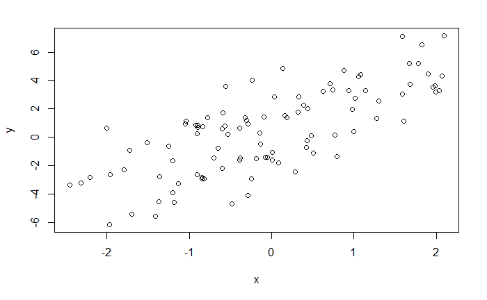

```r
plot(x,y)
```

```r
set.seed(10)
x <- rbinom(100, 1, 0.5)
e <- rnorm(100, 0, 2)
y <- 0.5 + 2 * x + e
summary(y)
```

```
   Min. 1st Qu.  Median    Mean 3rd Qu.    Max.
-3.4936 -0.1409  1.5767  1.4322  2.8397  6.9410
```

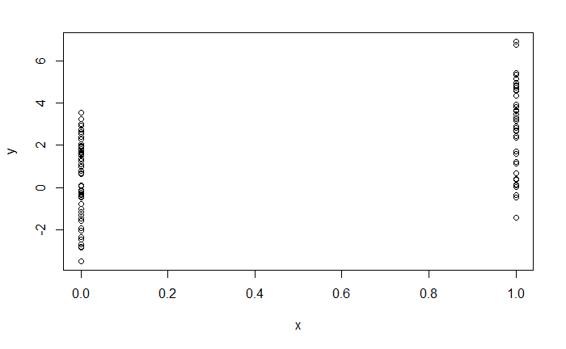

```r
plot(x,y)
```

```r
set.seed(1)
x <- rnorm(100)
log.mu <- 0.5 + 0.3*x
y <- rpois(100, exp(log.mu))
summary(y)
```

```
   Min. 1st Qu.  Median    Mean 3rd Qu.    Max.
   0.00    1.00    1.00    1.55    2.00    6.00
```

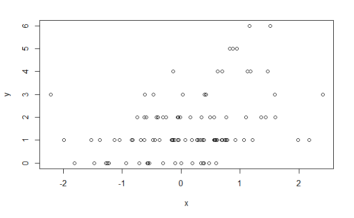

```r
plot(x,y)
```

## Sample Function

draws randomly from a specified set of scalar objects allowing you to sample from arb. distributions

```r
set.seed(1)
sample(1:10, 4)
```

```
[1] 9 4 7 1
```

```r
sample(1:10, 4)
```

```
[1] 2 7 3 6
```

```r
sample(letters, 5)
```

```
[1] "r" "s" "a" "u" "w"
```

```r
sample(1:10) ## Permutation
```

```
 [1] 10  6  9  2  1  5  8  4  3  7
```

```r
sample(1:10) ## Permutation
```

```
 [1]  5 10  2  8  6  1  4  3  9  7
```

```r
sample(1:10, replace = TRUE)
```

```
 [1]  3  6 10 10  6  4  4 10  9  7
```

# R Profiler

“Premature optimization is the root of all evil - Design FIRST, then OPTIMIZE”

```r
system.time(readLines("http://www.jhsph.edu"))
```

```
   user  system elapsed
   0.06    0.02    1.14
```

```r
hilbert <- function(n) {
  i <- 1:n
  1/outer(i -1, i, "+")}

x <- hilbert(1000)
system.time(svd(x))
```

```
   user  system elapsed
   2.79    0.03    2.86
```

For categorical variables (called ‘factor’ variables in R), summary() displays the number of times each value (or ‘level’)  
occurs in the data. For example, each value of Scientific_Name only appears once, since it is unique to a specific plant. In  
contrast, the summary for Duration (also a factor variable) tells us that our dataset contains 3031 Perennial plants, 682  
Annual plants, etc.